# Season 2: exploratory analysis

July 31, 2018

## Density & Detection Estimates

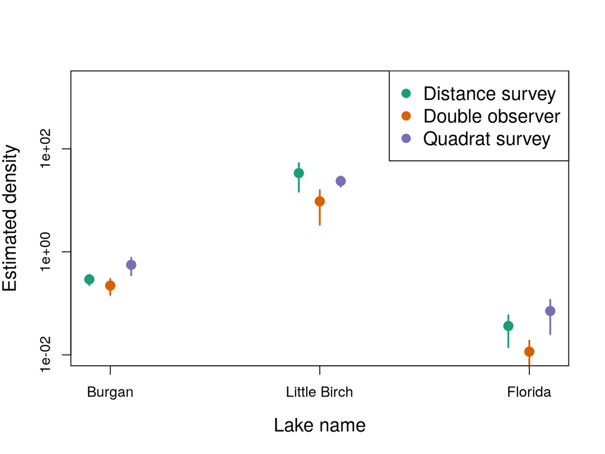

Y-axis is logarithmic. Bars are 2 standard errors.

There are a number of ways to estimate the variance in the surveyed data. We tested three on Lake Burgan below. The total variance in the double observer methods is given by $\mathrm{Var}(\hat{D})= \hat{D}^2\left(\frac{\mathrm{Var}(n)}{n^2} + \frac{\mathrm{Var(\mathrm{E}(s)}}{\mathrm{E}(s)^2} + \frac{\mathrm{Var}(a \hat{P})}{ (a \hat{P})^2 } \right)$. For a design-based estimate with $K$ transects each of length $l_k$ the first variance component is $\mathrm{Var}(n) = \left(\frac{\sum l_k}{K-1}\right) \displaystyle\sum l_k \left(\frac{n_k}{l_k} - \frac{\sum n_k}{\sum l_k} \right)^2$. Finally, we applied a model-based estimation process where transect counts were modeled as a negative binomial random variable. We used an offset in the model was the transect survey area times the estimated probability of detection in the transect.

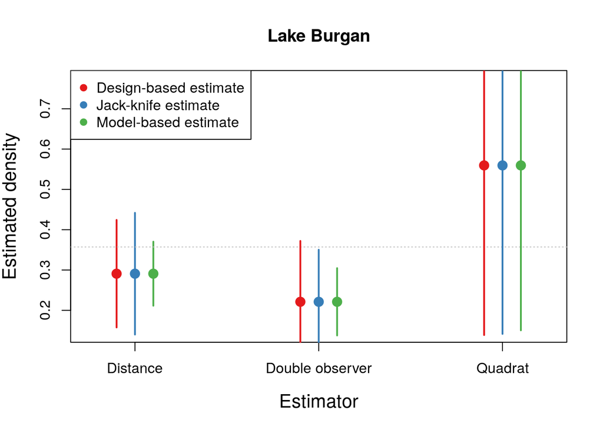

Variance estimators applied on each survey design type.

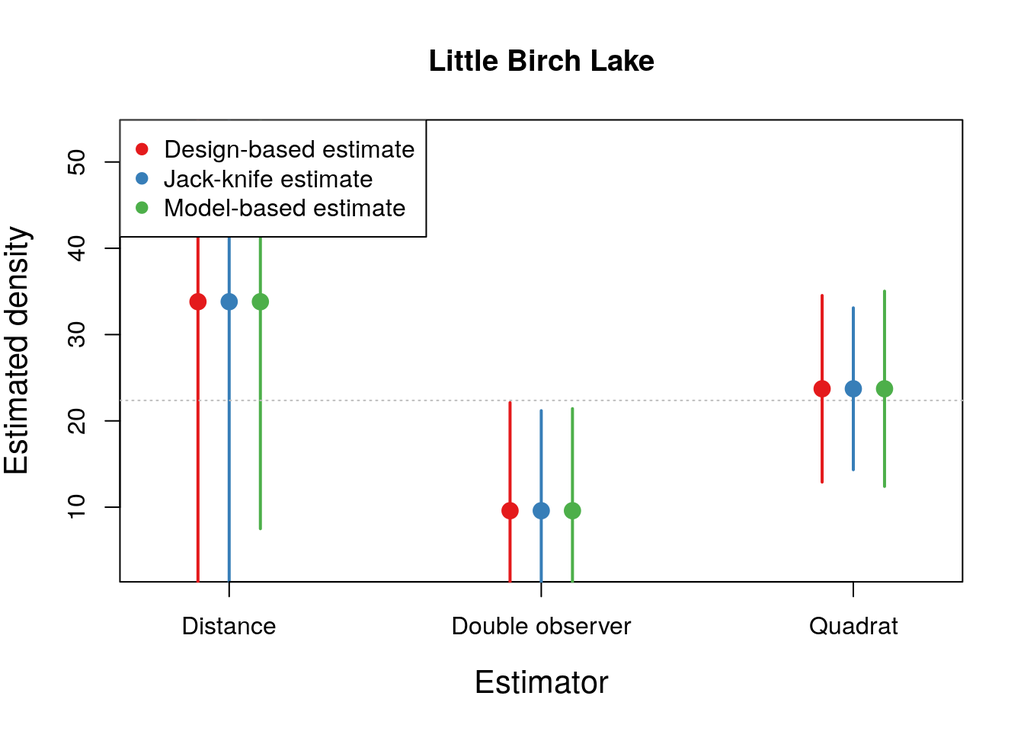

Variance estimators applied on each survey design type.

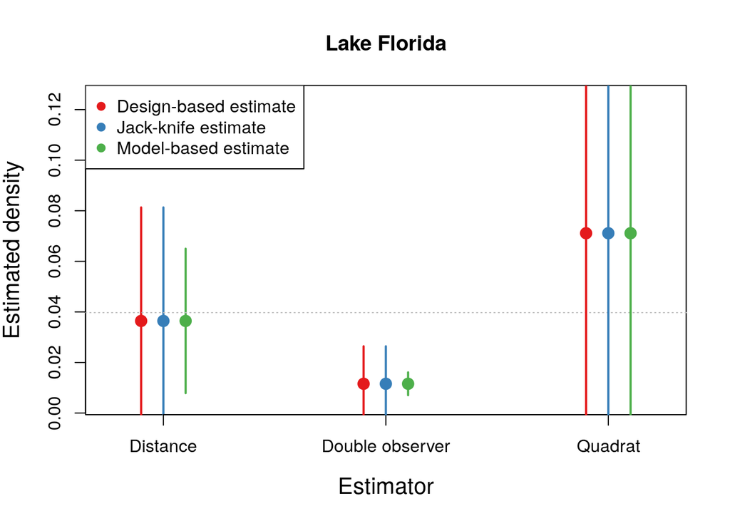

Variance estimators applied on each survey design type.

We can also look at the detection probabilities in each transect (Figure ). The detection probabilities of the distance survey are consistently lower than the double observer survey. The numbers are the pooled (total) number of detections by both observers. Note that I did not include observer effects in the models (both observers are assumed to have same detection probability).

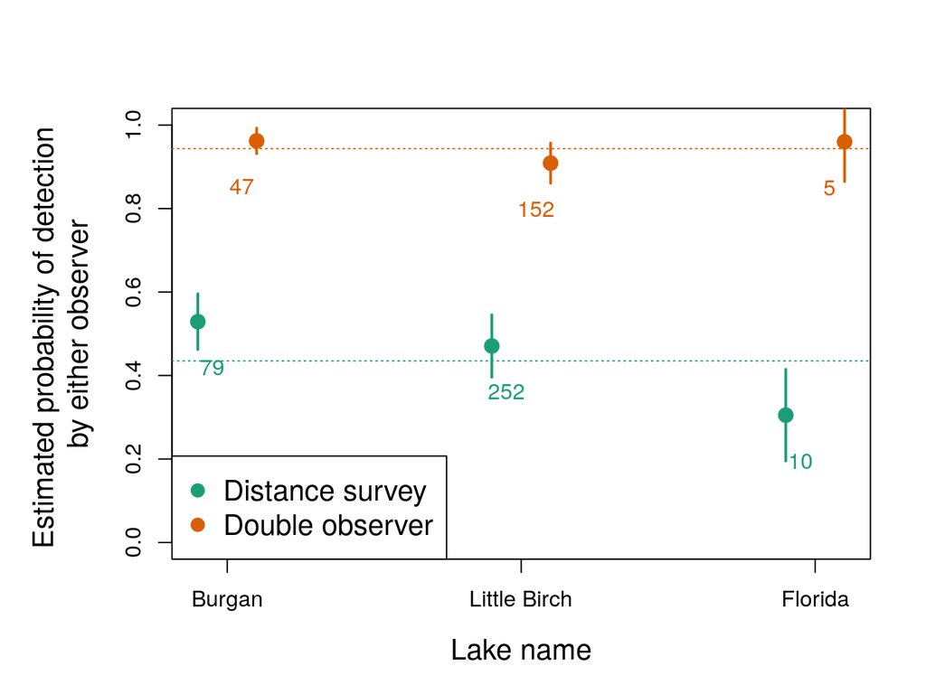

Numbers on the figure denote the total number of detections used to estimate detection probabilities. Bars are two standard errors. Horizontal dashed lines give the average of the lake estimates.

It’s not exactly clear why the double observer survey has such a higher detection than the distance survey, though the estimates are remarkably consistent for each survey type, regardless of sample size. Looking at the histogram of detections (along with the fitted detection model) may provide a clue (Figure ). I used the hazard-rate detection function, which has a shoulder after which detection falls off.

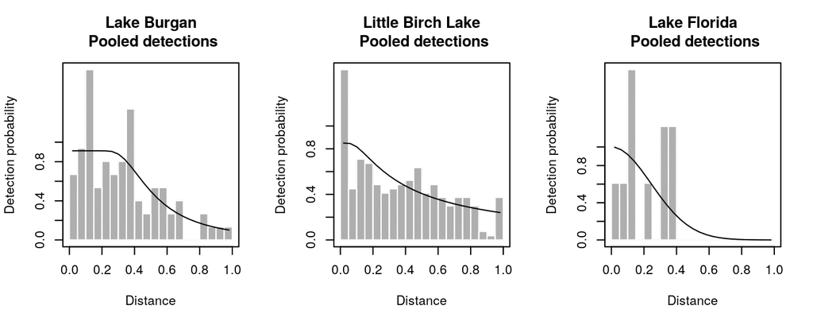

Figure in Burgan and Florida suggests that detection may fall off at about 0.5 meters. Data is extremely limited to infer any of these patterns, however. Little Birch Lake, which has the most detections, does not show this pattern…

Number of detections by primary and secondary observers. In the quadrat survey only one observer is used.

| Lake name | Distance survey Primary | Distance survey Secondary | Double observer survey Primary | Double observer survey Secondary | Quadrat survey Detections |
| --- | --- | --- | --- | --- | --- |
| Lake Burgan | 56 | 79 | 38 | 47 | 40 |
| Little Birch Lake | 165 | 252 | 112 | 152 | 1180 |
| Lake Florida | 10 | 10 | 4 | 5 | 8 |

Correlation between phase 2 detection rates and phase 3 densities estimated using Distance sampling, Double observer sampling, and Quadrat sampling.

|  | Distance | Double | Quadrat |
| --- | --- | --- | --- |
| Burgan | 0.18 | 0.33 | 0.42 |
| Little Birch | NA | 0.48 | 0.46 |
| Florida | -0.01 | -0.11 | -0.09 |

## Time Budget Summaries

We are also interested in how long it takes to do each task associated with the zebra mussel surveys. Figure is the overall amount of time spent doing a given type of survey versus the amount of area that was actually covered.

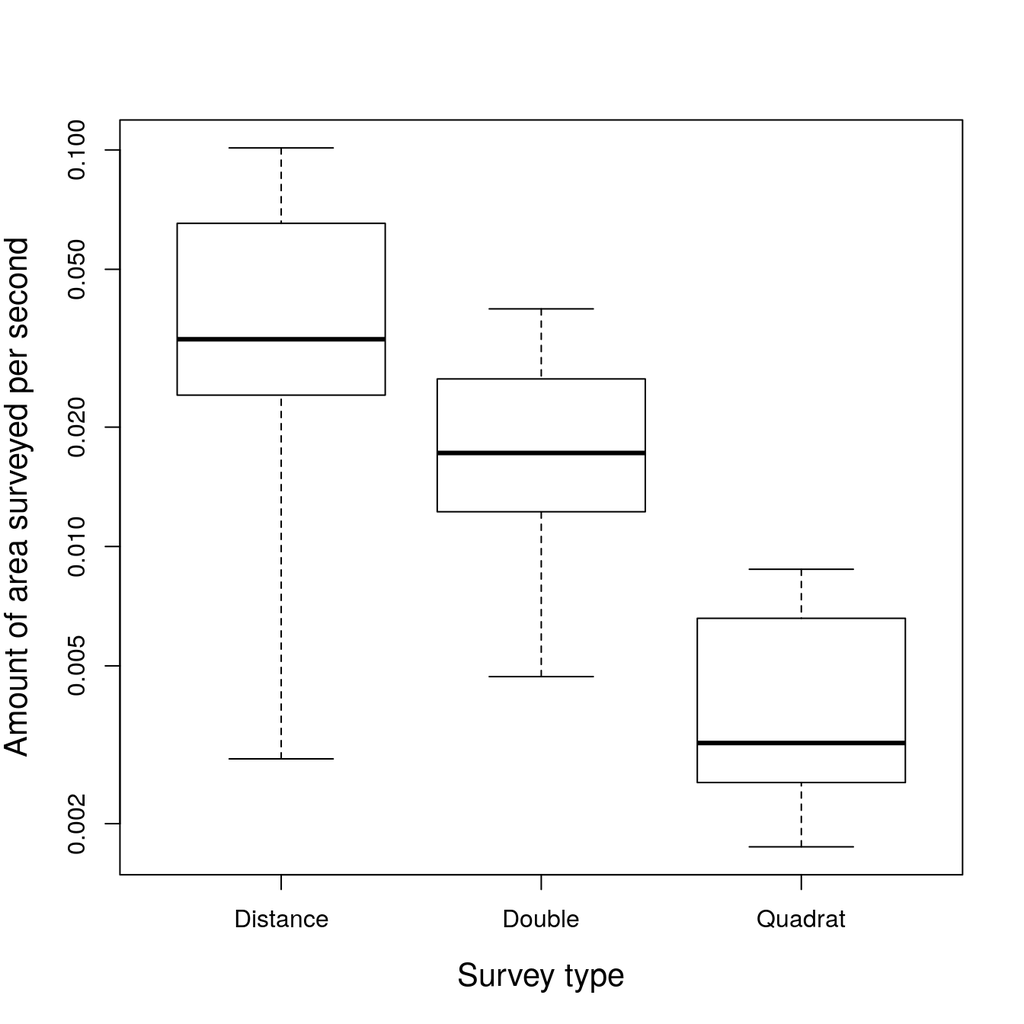

We see that the distance sampling is more efficient overall at covering area that the other types of survey.

We can also look at the time spent on the setup, taking habitat data, and on making and recording the encounters. This will allow us to better understand what is driving the relatively high efficiency of the distance surveys (Figure ).

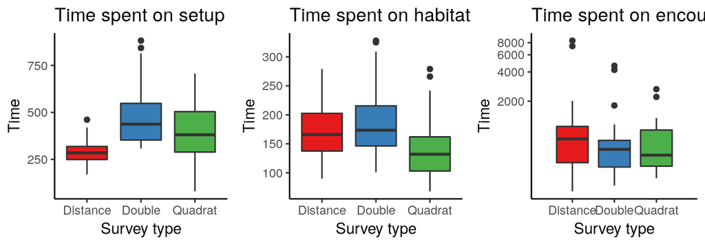

It appears that the economy of distance surveys is coming from the setup (laying out transect lines and taking transect-level data) of the transects. This is consistent with reports from the divers. We assumed that the amount of time spent on encounters in the double observer survey would be less than the distance survey, though Figure suggests that any differences are small enough not to matter in the overall efficiency. Note that these times are not standardized to transect lengths at all…

## Testing survey efficiency in a fixed amount of time

Here we will look at how to partition out a fixed amount of time into surveyed transects. We will look at the number of transects that can be achieved and the estimated variance in the density. First we modeled the amount of time spent at each lake to do setup, habitat, and encounters.

We fit some linear models for the setup time, habitat time, and time spent on encounters in Lake Burgan to determine how time spent on these various activities depended on the type of survey and on the survey length. We then predict the time that each of these activities on a 30-meter transect.

Times in seconds to perform various tasks on Lake Burgan in a 30-meter transect

|  | Setup time | Time to survey habitat | Time to conduct survey |
| --- | --- | --- | --- |
| Distance | 381.33 | 245.19 | 1471.54 |
| Double | 581.44 | 261.44 | 1103.20 |
| Quadrat | 482.06 | 221.91 | 709.27 |

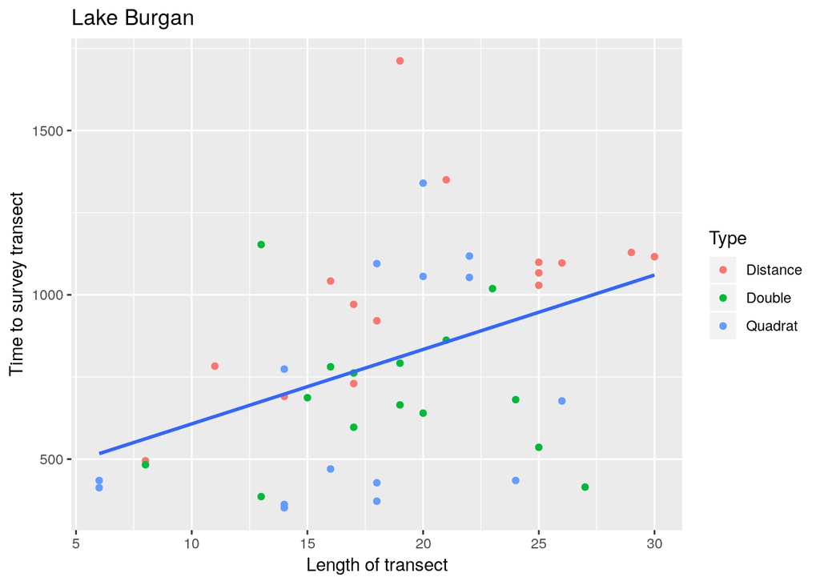

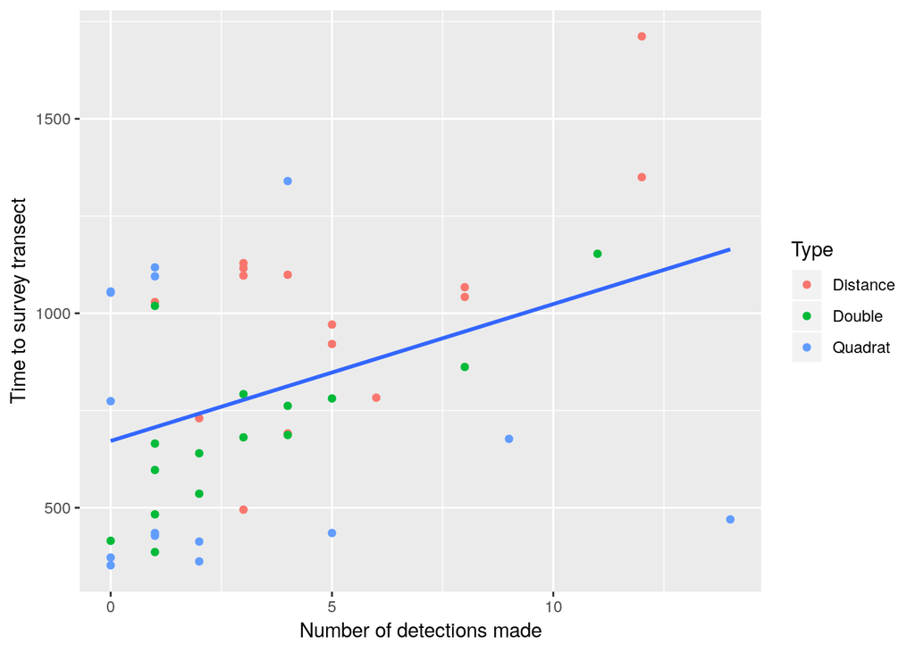

We also looked at the travel time between sites based on distance between sites. Below we see that there is a (pretty weak) relationship between distance traveled and the time it takes to move between sites. The model explains about 10% of the variation in the data.

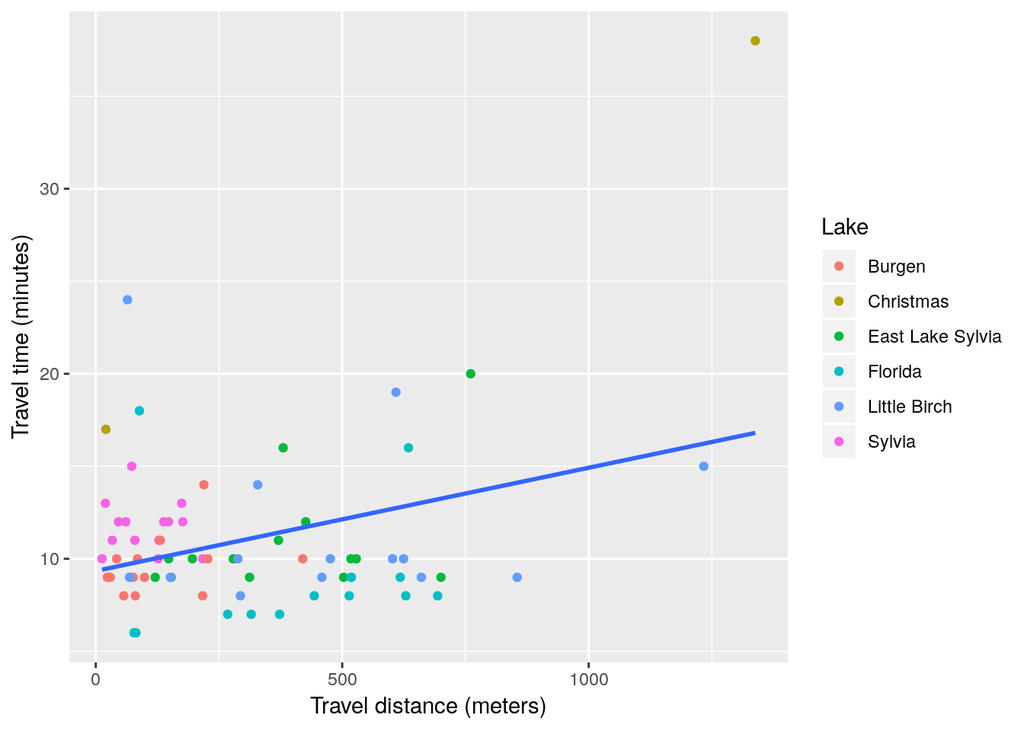

Moving between sites on Lake Burgan the average time is 10 minutes to travel 127 meters. Our model suggests that doubling this distance increases the travel time by 0.6 minutes. Below we plot our estimates of travel time for Lake Burgan and Lake Florida (still working on Little Birch Lake).

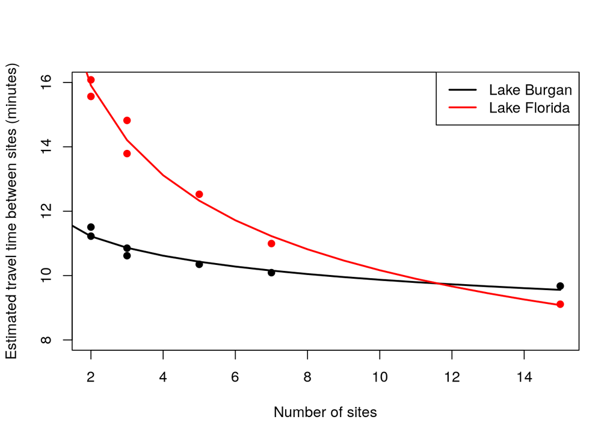

For a fixed time budget, many transects can you do using each survey method on each lake:

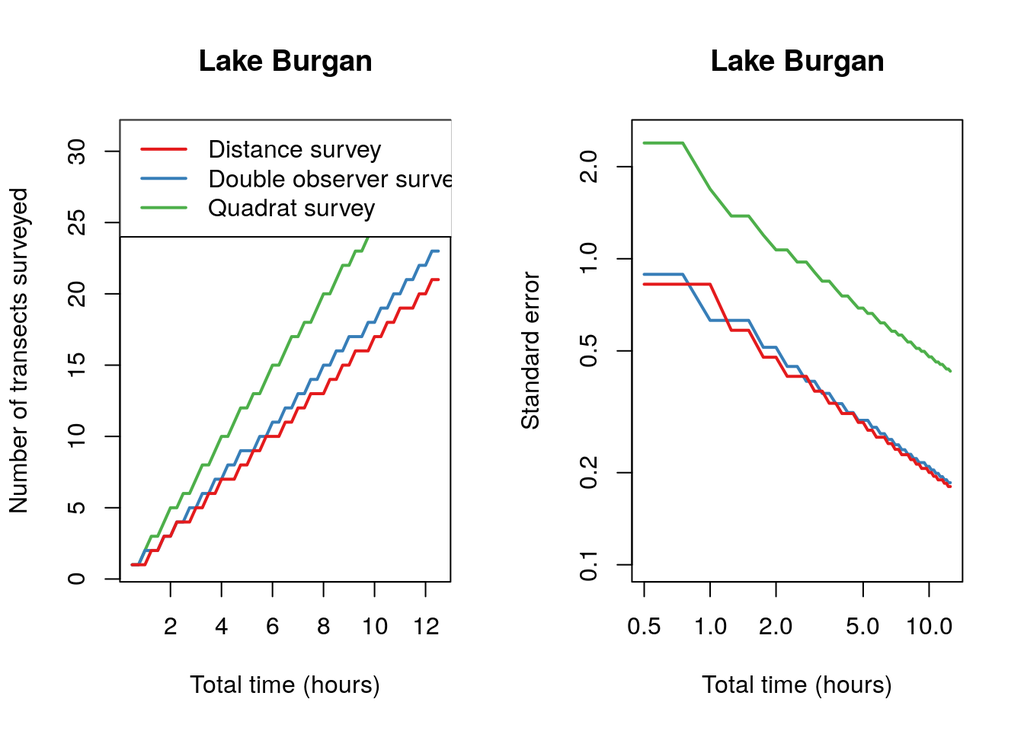

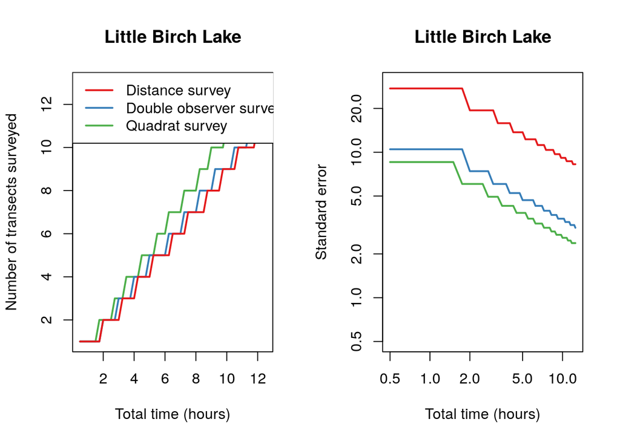

Times in seconds to perform various tasks on Little Birch Lake in a 30-meter transect

|  | Setup time | Time to survey habitat | Time to conduct survey |
| --- | --- | --- | --- |
| Distance | 314.81 | 225.59 | 2858.08 |
| Double | 514.92 | 241.85 | 2489.74 |
| Quadrat | 415.54 | 202.32 | 2095.81 |

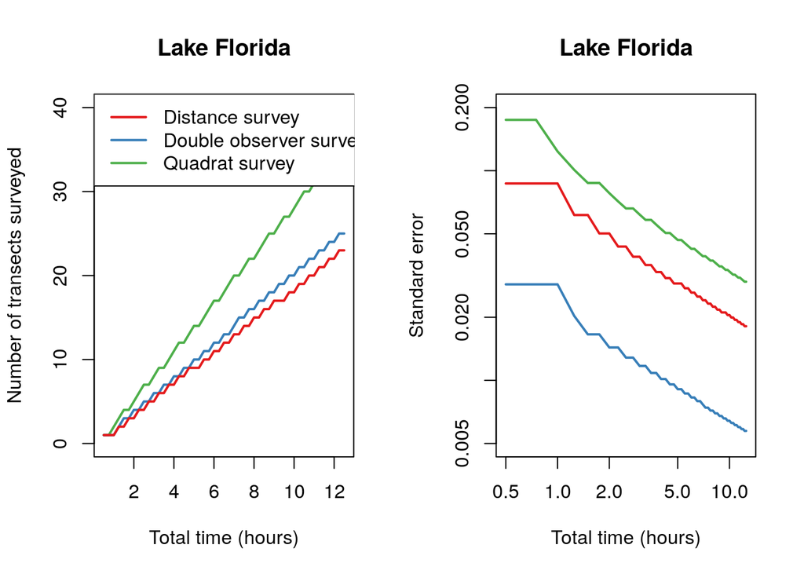

Times in seconds to perform various tasks on Lake Florida in a 30-meter transect

|  | Setup time | Time to survey habitat | Time to conduct survey |
| --- | --- | --- | --- |
| Distance | 286.69 | 169.13 | 873.74 |
| Double | 486.80 | 185.38 | 505.41 |
| Quadrat | 387.42 | 145.85 | 111.48 |